# Spatial Scripts

Raw group 100% MCP home range means of Stone Canyon and Owl Head Buttes. Grouped by environment and sex

```r
library(Rmisc)
YR_GRP_Means <- summarySE(year, measurevar="Home_Range_100mcp",
                          groupvars=c("Environment","Sex"),na.rm = TRUE)

kable(YR_GRP_Means, format = "pandoc",
      caption = 'Table 1 | Raw group 100% MCP home range means of Stone Canyon and Owl Head Buttes. Grouped by environment and sex.')
```

Raw group 95% MCP home range means of Stone Canyon and Owl Head Buttes. Grouped by environment and sex

```r
YR_GRP_Means95 <- summarySE(year, measurevar="Home_Range_95mcp",
                            groupvars=c("Environment","Sex"),na.rm = TRUE)

kable(YR_GRP_Means95, format = "pandoc", caption = 'Table 2 | Raw group 95% MCP home range means of raw data of Stone Canyon and Owl Head Buttes. Grouped by environment and sex.')
```

RM-ANOVA for 100% MCP analyses between the subsidized and non-subsidized

```r
# Get p-values from mixed model F values:
library(lme4)
library(readr)
year <- read_csv("GM_Consolidated_ByYear.csv")

RMmod.year<-lmer(Home_Range_100mcp~Environment+Year+Sex+N100+Environment*Sex+
                   (1|Gila),data = year)
summary(RMmod.year)
```

ANOVA table for 100% MCPs between the two populations

```r
anova(RMmod.year)
```

RM-ANOVA for 95% MCP analyses between the subsidized and non-subsidized

```r
RMmod.year95<-lmer(Home_Range_95mcp~Environment+Year+Sex+N100+Environment*Sex+
                   (1|Gila),data = year)
summary(RMmod.year95)
```

ANOVA table for 95% MCPs between the two populations

```r
anova(RMmod.year95)
```

Raw group means AND adjusted EMMs of Yearly Overall 100%MCP

```r
RMmod.year100<-lmer(Home_Range_100mcp~Environment+Year+Sex+N100+Environment*Sex+(1|Gila),data = year)

############################# EMMs adjusted #############################

RM.marginal <- lsmeans(RMmod.year100,
                    ~ Environment)

## CATAGORIZE LSM GRAPH BY SEX BETWEEN ENVIRONMENT:
refRM_sex <- lsmeans(RMmod.year100, specs = c("Environment","Sex"))

# refRM_sex
ref_dfRM_sex <- as.data.frame(summary(refRM_sex))
pd_RM <- position_dodge(0.1)

yr.mean.adj<-ggplot(ref_dfRM_sex, aes(x=Sex,y=lsmean,group=Environment))+
  geom_point(aes(shape = factor(Environment)), size = 3,position=position_dodge(.1),
            show.legend = FALSE)+
  geom_errorbar(aes(ymin=lsmean-SE, ymax=lsmean+SE), width=.1,position=position_dodge())+
  xlab("")+
  ylab("")

#yr.mean.adj

############################# Raw Group Means ############################
pd_RM <- position_dodge(0.1)

Raw.YearHR<-ggplot(YR_GRP_Means, aes(x=Sex,y=Home_Range_100mcp,group=Environment))+
  geom_point(aes(shape = factor(Environment)), size = 3,position=position_dodge(.1))+
  geom_errorbar(aes(ymin=Home_Range_100mcp-se, ymax=Home_Range_100mcp+se),
                width=.1,position=position_dodge())+
  xlab("")+
  ylab("100% MCP Area (ha)")


Raw.YearHR<-Raw.YearHR + theme(legend.title = element_blank(),
                     legend.text = element_text(size = 12),
                     legend.justification=c(0,1),
                     legend.position=c(0.05, 0.95),
                     legend.background = element_blank(),
                     legend.key = element_blank(),
                     legend.box.background = element_rect(colour = "black")) +
   scale_shape_discrete(name  ="",
                          breaks=c("nonsubsidized", "subsidized"),
                          labels=c("Nonsubsidized", "Subsidized"))

#Raw.YearHR

library(ggpubr)
library(gridExtra)
library(grid)

# grid.arrange(Raw.YearHR, yr.mean.adj, nrow = 1,
#              bottom = textGrob("Figure 5 | a. Raw group means of overall yearly home ranges between males and females. Note that the male \n home range of the subsidized population is smaller than that of the female home range in the non-subsidized \n population. b. Group means of home ranges after being adjusted for environment, year, sex, and sample size.",
#                                gp = gpar(fontface = 1,fontsize = 10),hjust = 0, x = 0))

# grid.arrange(Raw.YearHR, yr.mean.adj, nrow = 1)
# grid.arrange(Raw.YearHR, yr.mean.adj, nrow = 1)
# ggarrange(Raw.YearHR, yr.mean.adj, labels = c("A", "B"),
#           ncol = 2)
```

Directional means of home range (100% MCP) after being adjusted for year, sex and sample size

```r
kable(ref_dfRM_sex, format = "pandoc", caption = 'Table | Directional means of home range (100% MCP) after being adjusted for year, sex and sample size.')
```

RM-ANOVA of 95% KDEs for the subsidized population

```r
RM.KDEmod.year<-lmer(Home_Range_95kde~Year+Sex+N+(1|Gila),data = sub)

summary(RM.KDEmod.year)
```

ANOVA Table for 95%KDE

```r
anova(RM.KDEmod.year)
```

RM-ANOVA of 50% KDEs for the subsidized

```r
RM.KDE.50.mod.year<-lmer(Home_Range_50kde~Year+Sex+N+(1|Gila),data = sub)

summary(RM.KDE.50.mod.year)
```

ANOVA Talbe of 50% KDE for the subsidized

```r
anova(RM.KDE.50.mod.year)
```

TABLE. Raw Group 50% KDE home range means male and female home ranges at Stone Canyon

```r
YR_GRP_Means.50KDE <- summarySE(sub, measurevar="Home_Range_50kde",
                            groupvars=c("Sex"),na.rm = TRUE)

kable(YR_GRP_Means.50KDE, format = "pandoc", caption = 'Table 5 | Raw Group 50% KDE home range means male and female home ranges at Stone Canyon.')
```

Raw group means AND adjusted EMMs of Yearly Overall 95% KDEs between non/subsidized populations

```r
RMmod.95kde<-lmer(Home_Range_95kde~Environment+Year+Sex+N+Environment*Sex+(1|Gila),data = year)

############################ EMMs of 95% KDEs ###########################

RM.marginal <- lsmeans(RMmod.95kde,
                       ~ Environment)

## CATAGORIZE LSM GRAPH BY SEX BETWEEN ENVIRONMENT:
refRM_kde <- lsmeans(RMmod.95kde, specs = c("Environment","Sex"))

# refRM_sex
ref_dfRM_kde <- as.data.frame(summary(refRM_kde))
pd_RM <- position_dodge(0.1)

kde.mean.adj<-ggplot(ref_dfRM_kde, aes(x=Sex,y=lsmean,group=Environment))+
  geom_point(aes(shape = factor(Environment)), size = 3,position=position_dodge(.1),
             show.legend = FALSE)+
  geom_errorbar(aes(ymin=lsmean-SE, ymax=lsmean+SE), width=.1,position=position_dodge())+
  xlab("")+
  ylab("")

# kde.mean.adj

############################ raw EMMs of 95% KDEs ###########################

pd_RM <- position_dodge(0.1)

Raw.kde<-ggplot(YR_Means.95KDEall, aes(x=Sex,y=Home_Range_95kde,group=Environment))+
  geom_point(aes(shape = factor(Environment)), size = 3,position=position_dodge(.1),
             show.legend = FALSE)+
  geom_errorbar(aes(ymin=Home_Range_95kde-se, ymax=Home_Range_95kde+se),
                width=.1, position=position_dodge())+
  xlab("")+
  ylab("95% KDE Area (ha)")
Raw.kde
# Raw.kde<-Raw.kde + theme(legend.title = element_blank(),
#                                legend.text = element_text(size = 12),
#                                legend.justification=c(0,1),
#                                legend.position=c(0.05, 0.95),
#                                legend.background = element_blank(),
#                                legend.key = element_blank(),
#                                legend.box.background = element_rect(colour = "black")) +
#   scale_shape_discrete(name  ="",
#                        breaks=c("nonsubsidized", "subsidized"),
#                        labels=c("Nonsubsidized", "Subsidized"))
# Raw.kde

library(gridExtra)
library(grid)

# ggarrange(Raw.kde, kde.mean.adj, labels = c("A", "B"),
#           nrow = 1)
```

Yearly overall means of 95% KDEs grouped by site and sex

```r
YR_Means.95KDEall <- summarySE(year, measurevar="Home_Range_95kde",
                            groupvars=c("Environment","Sex"),na.rm = TRUE)

kable(YR_Means.95KDEall, format = "pandoc", caption = 'Table | Raw Group 95% KDE home range means male and female home ranges at non/subsidized.')
```

Collective grid of 100% MCP and 95% KDE of both sites from above

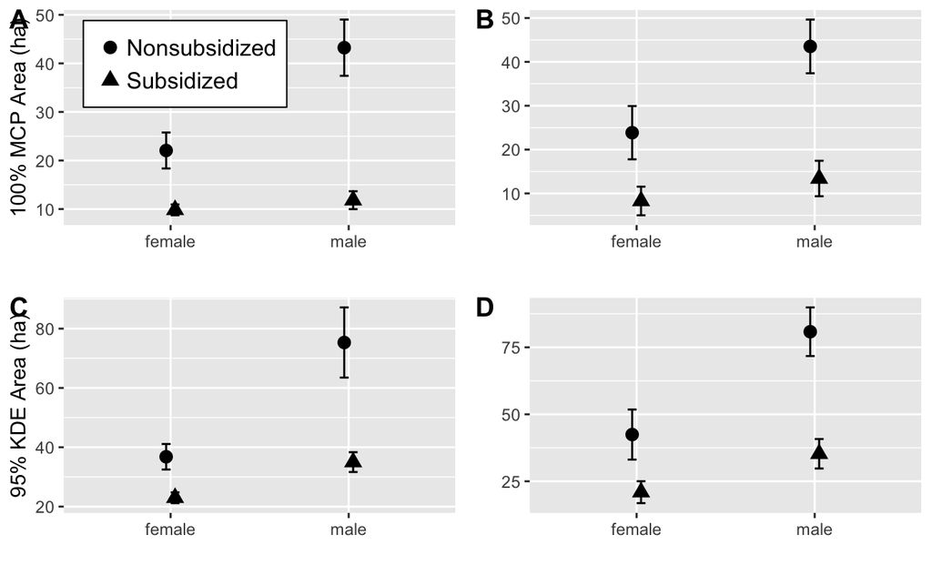

```r
ggarrange(Raw.YearHR, yr.mean.adj, Raw.kde, kde.mean.adj, labels = c("A", "B", "C","D"),
          ncol = 2, nrow = 2)
```

```r
RMmod.year.Em<-lmer(Home_Range_100mcp~Environment+Year+Sex+N100+Environment*Sex+
                      (1|Gila),data = year)

# RMmod.year.Em95<-lmer(Home_Range_95mcp~Environment+Year+Sex+N95+Environment*Sex+
#                       (1|Gila),data = year)

# Sex.emm.oa <- emmeans(RMmod.year.Em, c("Environment","Sex"))
# pairs(Sex.emm.oa)

emm_s.t2 <- emmeans(RMmod.year.Em, pairwise ~ Sex | Environment)
emm_s.t2
# emm_s.e1 <- emmeans(RMmod.year.Em, pairwise ~ Environment)
# emm_s.e1
```

Graphical Comparisons of Sex Within Each Environment:

```r
plot(emm_s.t2, comparisons = TRUE, xlab = "Least Square Mean (ha)", ylab = "Environment")
```

[output not shown]

```r
emm_s.t3 <- emmeans(RMmod.year.Em, pairwise ~ Environment | Sex)
emm_s.t3

# emm_s.t95 <- emmeans(RMmod.year.Em95, pairwise ~ Environment | Sex)
# emm_s.t95
```

Graphical Comparisons of Sex between the two populations:

```r
plot(emm_s.t3, comparisons = TRUE, xlab = "Least Square Mean (ha)", ylab = "Environment")
```

[output not shown]

Ineractive map of MCPs at Stone Canyon

```r
M67_MCP<-mcp_analysis.POLY('./M67/M67 .csv', percentage= 100)
M69_MCP<-mcp_analysis.POLY('./M69/M69 .csv', percentage= 100)
M255_MCP<-mcp_analysis.POLY('./M255/M255 .csv', percentage= 100)
M215_MCP<-mcp_analysis.POLY('./M215/M215 .csv', percentage= 100)
M14_MCP<-mcp_analysis.POLY('./M14/M14 .csv', percentage= 100)
M119_MCP<-mcp_analysis.POLY('./M119/M119 .csv', percentage= 100)
M112_MCP<-mcp_analysis.POLY('./M112/M112 .csv', percentage= 100)

F66_MCP<-mcp_analysis.POLY('./F66/F66 .csv', percentage= 100)
F36_MCP<-mcp_analysis.POLY('./F36/F36 .csv', percentage= 100)
F252_MCP<-mcp_analysis.POLY('./F252/F252 .csv', percentage= 100)
F214_MCP<-mcp_analysis.POLY('./F214/F214 .csv', percentage= 100)
F200_MCP<-mcp_analysis.POLY('./F200/F200 .csv', percentage= 100)
F147_MCP<-mcp_analysis.POLY('./F147/F147 .csv', percentage= 100)
F146_MCP<-mcp_analysis.POLY('./F146/F146 .csv', percentage= 100)
F137_MCP<-mcp_analysis.POLY('./F137/F137 .csv', percentage= 100)
F135_MCP<-mcp_analysis.POLY('./F135/F135 .csv', percentage= 100)
F114_MCP<-mcp_analysis.POLY('./F114/F114 .csv', percentage= 100)
F104_MCP<-mcp_analysis.POLY('./F104/F104 .csv', percentage= 100)

Male.MCP <- rbind(M67_MCP,M69_MCP,M255_MCP,M215_MCP,M14_MCP,M119_MCP,M112_MCP)
Female.MCP <- rbind(F66_MCP,F36_MCP,F252_MCP,F214_MCP,F200_MCP,F147_MCP,F146_MCP,F137_MCP,
                    F135_MCP,F114_MCP,F104_MCP)

mapviewOptions(basemaps = c("OpenStreetMap","Esri.WorldImagery","OpenTopoMap"),
               na.color = "magenta",
               layers.control.pos = "topleft")

mapview(Male.MCP, legend=F, zcol="id", col.regions = c("blue"), alpha.regions=0.3) +
  mapview(Female.MCP, legend=F, zcol = "id", col.regions = c("red"), alpha.regions=0.3)
```

[output not shown]

Create stagnant stamen map of MCPs at Stone Canyon

```r
SC_stamen_map<-SC_stamen_map + ggsn::scalebar(x.min = -110.972, x.max = -110.966,
                     y.min = 32.474, y.max = 32.476,
                     dist = 500, dist_unit="m",
                     height=0.19,
                     st.bottom=TRUE,
                     st.dist=0.3,
                     st.size=3.5,
                     transform = TRUE,
                     model = 'WGS84')
SC_stamen_map
SC_stamen_map+north2(SC_stamen_map, x = 0.89, y = 0.85, scale = 0.1, symbol = 16)
```

[output not shown]

Interactive map of KDEs at Stone Canyon

```r
M67_KDE<-kde_analysis.href.polygon('./M67/M67 .csv', percentage= 95)
M69_KDE<-kde_analysis.href.polygon('./M69/M69 .csv', percentage= 95)
M255_KDE<-kde_analysis.href.polygon('./M255/M255 .csv', percentage= 95)
M215_KDE<-kde_analysis.href.polygon('./M215/M215 .csv', percentage= 95)
M14_KDE<-kde_analysis.href.polygon('./M14/M14 .csv', percentage= 95)
M119_KDE<-kde_analysis.href.polygon('./M119/M119 .csv', percentage= 95)
M112_KDE<-kde_analysis.href.polygon('./M112/M112 .csv', percentage= 95)

F66_KDE<-kde_analysis.href.polygon('./F66/F66 .csv', percentage= 95)
F36_KDE<-kde_analysis.href.polygon('./F36/F36 .csv', percentage= 95)
F252_KDE<-kde_analysis.href.polygon('./F252/F252 .csv', percentage= 95)
F214_KDE<-kde_analysis.href.polygon('./F214/F214 .csv', percentage= 95)
F200_KDE<-kde_analysis.href.polygon('./F200/F200 .csv', percentage= 95)
F147_KDE<-kde_analysis.href.polygon('./F147/F147 .csv', percentage= 95)
F146_KDE<-kde_analysis.href.polygon('./F146/F146 .csv', percentage= 95)
F137_KDE<-kde_analysis.href.polygon('./F137/F137 .csv', percentage= 95)
F135_KDE<-kde_analysis.href.polygon('./F135/F135 .csv', percentage= 95)
F114_KDE<-kde_analysis.href.polygon('./F114/F114 .csv', percentage= 95)
F104_KDE<-kde_analysis.href.polygon('./F104/F104 .csv', percentage= 95)

Male.KDE <- rbind(M67_KDE,M69_KDE,M255_KDE,M215_KDE,M14_KDE,M119_KDE,M112_KDE)
Female.KDE <- rbind(F66_KDE,F36_KDE,F252_KDE,F214_KDE,F200_KDE,F147_KDE,F146_KDE,F137_KDE,
                    F135_KDE,F114_KDE,F104_KDE)

mapviewOptions(basemaps = c("OpenStreetMap","Esri.WorldImagery","OpenTopoMap"),
               na.color = "magenta",
               layers.control.pos = "topleft")

mapview(Male.KDE, legend=F, zcol="id", col.regions = c("blue"), alpha.regions=0.3) +
  mapview(Female.KDE, legend=F, zcol = "id", col.regions = c("red"), alpha.regions=0.3)
```

[output not shown]

TABLE

Table | Subsidized and non-subsidized directional means of KDE home ranges after being adjusted for year, sex and sample size.

| Environment | Sex | lsmean | SE | df | lower.CL | upper.CL |
| --- | --- | --- | --- | --- | --- | --- |
| nonsubsidized | female | 42.44837 | 9.346459 | 53.01148 | 23.70185 | 61.19490 |
| subsidized | female | 20.93992 | 4.083131 | 22.92042 | 12.49169 | 29.38814 |
| nonsubsidized | male | 80.81873 | 9.084540 | 52.50968 | 62.59348 | 99.04398 |
| subsidized | male | 35.27439 | 5.501543 | 29.24014 | 24.02648 | 46.52229 |

SEASONAL ANALYSES

Map of seasonal fluctions of home ranges

```r
## Create MCP polygons by SEASON:
M215_mcp.EM<-mcp_analysis.POLY("./M215/Emergence .csv", percentage= 100)
M215_mcp.DRY<-mcp_analysis.POLY("./M215/Dry .csv", percentage= 100)
M215_mcp.MON<-mcp_analysis.POLY("./M215/Monsoon .csv", percentage= 100)

M112_mcp.DRY<-mcp_analysis.POLY("./M112/Dry .csv", percentage= 100)
M112_mcp.MON<-mcp_analysis.POLY("./M112/Monsoon .csv", percentage= 100)
M112_mcp.PM<-mcp_analysis.POLY("./M112/Post_Monsoon .csv", percentage= 100)

M119_mcp.DRY<-mcp_analysis.POLY("./M119/Dry .csv", percentage= 100)
M119_mcp.MON<-mcp_analysis.POLY("./M119/Monsoon .csv", percentage= 100)
M119_mcp.PM<-mcp_analysis.POLY("./M119/Post_Monsoon .csv", percentage= 100)

F114_mcp.EM<-mcp_analysis.POLY("./F114/Emergence .csv", percentage= 100)
F114_mcp.DRY<-mcp_analysis.POLY("./F114/Dry .csv", percentage= 100)
F114_mcp.MON<-mcp_analysis.POLY("./F114/Monsoon .csv", percentage= 100)
F114_mcp.PM<-mcp_analysis.POLY("./F114/Post_Monsoon .csv", percentage= 100)

F137_mcp.EM<-mcp_analysis.POLY("./F137/Emergence .csv", percentage= 100)
F137_mcp.DRY<-mcp_analysis.POLY("./F137/Dry .csv", percentage= 100)
F137_mcp.MON<-mcp_analysis.POLY("./F137/Monsoon .csv", percentage= 100)
F137_mcp.PM<-mcp_analysis.POLY("./F137/Post_Monsoon .csv", percentage= 100)

F147_mcp.EM<-mcp_analysis.POLY("./F147/Emergence .csv", percentage= 100)
F147_mcp.DRY<-mcp_analysis.POLY("./F147/Dry .csv", percentage= 100)
F147_mcp.MON<-mcp_analysis.POLY("./F147/Monsoon .csv", percentage= 100)
F147_mcp.PM<-mcp_analysis.POLY("./F147/Post_Monsoon .csv", percentage= 100)

F252_mcp.EM<-mcp_analysis.POLY("./F252/Emergence .csv", percentage= 100)
F252_mcp.DRY<-mcp_analysis.POLY("./F252/Dry .csv", percentage= 100)
F252_mcp.MON<-mcp_analysis.POLY("./F252/Monsoon .csv", percentage= 100)
F252_mcp.PM<-mcp_analysis.POLY("./F252/Post_Monsoon .csv", percentage= 100)

F36_mcp.EM<-mcp_analysis.POLY("./F36/Emergence .csv", percentage= 100)
F36_mcp.DRY<-mcp_analysis.POLY("./F36/Dry .csv", percentage= 100)
F36_mcp.MON<-mcp_analysis.POLY("./F36/Monsoon .csv", percentage= 100)
F36_mcp.PM<-mcp_analysis.POLY("./F36/Post_Monsoon .csv", percentage= 100)

F66_mcp.EM<-mcp_analysis.POLY("./F66/Emergence .csv", percentage= 100)
F66_mcp.DRY<-mcp_analysis.POLY("./F66/Dry .csv", percentage= 100)
F66_mcp.MON<-mcp_analysis.POLY("./F66/Monsoon .csv", percentage= 100)
F66_mcp.PM<-mcp_analysis.POLY("./F66/Post_Monsoon .csv", percentage= 100)

## Fortify mcp polygons for ggplot2 *SEASON*:
M215_mcp.EMT <- fortify(M215_mcp.EM, region = "id")
M215_mcp.DRYT <- fortify(M215_mcp.DRY, region = "id")
M215_mcp.MONT <- fortify(M215_mcp.MON, region = "id")

M112_mcp.DRYT <- fortify(M112_mcp.DRY, region = "id")
M112_mcp.MONT <- fortify(M112_mcp.MON, region = "id")
M112_mcp.PMT <- fortify(M112_mcp.PM, region = "id")

M119_mcp.DRYT <- fortify(M119_mcp.DRY, region = "id")
M119_mcp.MONT <- fortify(M119_mcp.MON, region = "id")
M119_mcp.PMT <- fortify(M119_mcp.PM, region = "id")

F114_mcp.EMT <- fortify(F114_mcp.EM, region = "id")
F114_mcp.DRYT <- fortify(F114_mcp.DRY, region = "id")
F114_mcp.MONT <- fortify(F114_mcp.MON, region = "id")
F114_mcp.PMT <- fortify(F114_mcp.PM, region = "id")

F137_mcp.EMT <- fortify(F137_mcp.EM, region = "id")
F137_mcp.DRYT <- fortify(F137_mcp.DRY, region = "id")
F137_mcp.MONT <- fortify(F137_mcp.MON, region = "id")
F137_mcp.PMT <- fortify(F137_mcp.PM, region = "id")

F147_mcp.EMT <- fortify(F147_mcp.EM, region = "id")
F147_mcp.DRYT <- fortify(F147_mcp.DRY, region = "id")
F147_mcp.MONT <- fortify(F147_mcp.MON, region = "id")
F147_mcp.PMT <- fortify(F147_mcp.PM, region = "id")

F252_mcp.EMT <- fortify(F252_mcp.EM, region = "id")
F252_mcp.DRYT <- fortify(F252_mcp.DRY, region = "id")
F252_mcp.MONT <- fortify(F252_mcp.MON, region = "id")
F252_mcp.PMT <- fortify(F252_mcp.PM, region = "id")

F36_mcp.EMT <- fortify(F36_mcp.EM, region = "id")
F36_mcp.DRYT <- fortify(F36_mcp.DRY, region = "id")
F36_mcp.MONT <- fortify(F36_mcp.MON, region = "id")
F36_mcp.PMT <- fortify(F36_mcp.PM, region = "id")

F66_mcp.EMT <- fortify(F66_mcp.EM, region = "id")
F66_mcp.DRYT <- fortify(F66_mcp.DRY, region = "id")
F66_mcp.MONT <- fortify(F66_mcp.MON, region = "id")
F66_mcp.PMT <- fortify(F66_mcp.PM, region = "id")

mcp.shift.TEST5 <- ggplot() +
  geom_polygon(data=F114_mcp.EMT, aes(x=F114_mcp.EMT$long, y=F114_mcp.EMT$lat),
               alpha=0.1,colour="blue",linetype=2) +
  geom_polygon(data=F114_mcp.DRYT, aes(x=F114_mcp.DRYT$long, y=F114_mcp.DRYT$lat),
               alpha=0.1,colour="red",linetype=3) +
  geom_polygon(data=F114_mcp.MONT, aes(x=F114_mcp.MONT$long, y=F114_mcp.MONT$lat),
               alpha=0.1,colour="green",linetype=4) +
  geom_polygon(data=F114_mcp.PMT, aes(x=F114_mcp.PMT$long, y=F114_mcp.PMT$lat),
               alpha=0.1,colour="black",linetype=5) +
  geom_polygon(data=F137_mcp.EMT, aes(x=F137_mcp.EMT$long, y=F137_mcp.EMT$lat),
               alpha=0.1,colour="blue",linetype=2) +
  geom_polygon(data=F137_mcp.DRYT, aes(x=F137_mcp.DRYT$long, y=F137_mcp.DRYT$lat),
               alpha=0.1,colour="red",linetype=3) +
  geom_polygon(data=F137_mcp.MONT, aes(x=F137_mcp.MONT$long, y=F137_mcp.MONT$lat),
               alpha=0.1,colour="green",linetype=4) +
  geom_polygon(data=F137_mcp.PMT, aes(x=F137_mcp.PMT$long, y=F137_mcp.PMT$lat),
               alpha=0.1,colour="black",linetype=5) +
  geom_polygon(data=F147_mcp.EMT, aes(x=F147_mcp.EMT$long, y=F147_mcp.EMT$lat),
               alpha=0.1,colour="blue",linetype=2) +
  geom_polygon(data=F147_mcp.DRYT, aes(x=F147_mcp.DRYT$long, y=F147_mcp.DRYT$lat),
               alpha=0.1,colour="red",linetype=3) +
  geom_polygon(data=F147_mcp.MONT, aes(x=F147_mcp.MONT$long, y=F147_mcp.MONT$lat),
               alpha=0.1,colour="green",linetype=4) +
  geom_polygon(data=F147_mcp.PMT, aes(x=F147_mcp.PMT$long, y=F147_mcp.PMT$lat),
               alpha=0.1,colour="black",linetype=5) +
  # geom_polygon(data=F252_mcp.EMT, aes(x=F252_mcp.EMT$long, y=F252_mcp.EMT$lat),
  #              alpha=0.1,colour="black",linetype=2) +
  # geom_polygon(data=F252_mcp.DRYT, aes(x=F252_mcp.DRYT$long, y=F252_mcp.DRYT$lat),
  #              alpha=0.1,colour="black",linetype=3) +
  # geom_polygon(data=F252_mcp.MONT, aes(x=F252_mcp.MONT$long, y=F252_mcp.MONT$lat),
  #              alpha=0.1,colour="black",linetype=4) +
  # geom_polygon(data=F252_mcp.PMT, aes(x=F252_mcp.PMT$long, y=F252_mcp.PMT$lat),
  #              alpha=0.1,colour="black",linetype=5) +
  geom_polygon(data=F36_mcp.EMT, aes(x=F36_mcp.EMT$long, y=F36_mcp.EMT$lat),
               alpha=0.1,colour="blue",linetype=2) +
  geom_polygon(data=F36_mcp.DRYT, aes(x=F36_mcp.DRYT$long, y=F36_mcp.DRYT$lat),
               alpha=0.1,colour="red",linetype=3) +
  geom_polygon(data=F36_mcp.MONT, aes(x=F36_mcp.MONT$long, y=F36_mcp.MONT$lat),
               alpha=0.1,colour="green",linetype=4) +
  geom_polygon(data=F36_mcp.PMT, aes(x=F36_mcp.PMT$long, y=F36_mcp.PMT$lat),
               alpha=0.1,colour="black",linetype=5) +
  geom_polygon(data=F66_mcp.EMT, aes(x=F66_mcp.EMT$long, y=F66_mcp.EMT$lat),
               alpha=0.1,colour="blue",linetype=2) +
  geom_polygon(data=F66_mcp.DRYT, aes(x=F66_mcp.DRYT$long, y=F66_mcp.DRYT$lat),
               alpha=0.1,colour="red",linetype=3) +
  geom_polygon(data=F66_mcp.MONT, aes(x=F66_mcp.MONT$long, y=F66_mcp.MONT$lat),
               alpha=0.1,colour="green",linetype=4) +
  geom_polygon(data=F66_mcp.PMT, aes(x=F66_mcp.PMT$long, y=F66_mcp.PMT$lat),
               alpha=0.1,colour="black",linetype=5) +
  theme_bw() +
  labs(x="Easting (m)", y="Northing (m)") +
  labs(caption = "Figure 6 |  SC seasonal home range shifts of five lizards. All seasonal polygons stay relatively stable with \n considerable overlap and without any major shifts.")+
  theme(plot.caption = element_text(hjust = 0,lineheight = 0.9))+
  theme(legend.position="none", plot.title = element_text(face = "bold", hjust = 0.5))

mcp.shift.TEST5
```

[output not shown]

TABLE group means of seasonal home ranges between the two populations averaged across sex

```r
seasonal<-read.csv("SC_Seasonal_Data.csv")

library(Rmisc)

SEAS_GRP_Means <- summarySE(seasonal, measurevar="Home_Range_100mcp",
                            groupvars=c("Environment","Season"), na.rm = TRUE)

# SEAS_GRP_Means
kable(SEAS_GRP_Means, format = "pandoc", caption = 'Table 6 | Group means of seasonal home ranges between Stone Canyon (subsidized) and Owl Head Buttes (non-subsidized). These means are averaged across sex.')
```

RM-ANOVA for seasonal home ranges between environments

```r
library(lme4)
library(readr)
library(lmerTest)
# seasonal<-read.csv("SC_Seasonal_Data.csv")

RM.mod.Season <- lmer(Home_Range_100mcp~Environment+Season+Sex+N+Environment*Season+(1|Gila),
                      data=seasonal)
summary(RM.mod.Season)
```

ANOVA table of seasonal HRs between envs.

```r
anova(RM.mod.Season)
```

TABLE of seasonal home ranges by sex between the two populations

```r
SEAS_GRP_TEST <- summarySE(seasonal, measurevar="Home_Range_100mcp",
                           groupvars=c("Environment","Season","Sex"), na.rm = TRUE)

# SEAS_GRP_Means
kable(SEAS_GRP_TEST, format = "pandoc", caption = 'Table 7 | Seasonal home range means between Stone Canyon (subsidized) and Owl Head Buttes (non-subsidized) popuations for males and females. These are raw means before being adjusted for environment, season, sex, and sample size.')
```

figures for raw seasonal home ranges between the two populations

```r
pd <- position_dodge(0.3) # move them .05 to the left and right ('dodges')

# To change plot order of facet wrap,
# change the order of varible levels with factor()
# year$Season <- factor(year$Season, levels = c("Emergence", "Dry", "Monsoon", "Post_Monsoon"))
# f=c('Emergence','Dry','Monsoon', 'Post_Monsoon')
# year <- within(year, Season <- factor(Season, levels=f))

# New facet label names for seasons
season.labs <- c("Dry", "Emergence", "Monsoon", "Post Monsoon")
names(season.labs) <- c("Dry", "Emergence", "Monsoon", "Post_Monsoon")

## TEST 3
raw.seasonal<-ggplot(SEAS_GRP_TEST,aes(x=Environment, y=Home_Range_100mcp, shape=Sex)) +
  geom_point(aes(shape=Sex), size = 3, position=pd) +
  geom_errorbar(aes(ymin=Home_Range_100mcp-se, ymax=Home_Range_100mcp+se), position = pd,
                width=0.3, size=0.5, lty=1) +
  # scale_colour_manual(values = c('black','red')) +
  facet_grid(~Season, labeller=labeller(Season=season.labs)) +
  # scale_shape_manual(values = c(8,19))+
  # labs(caption = "Figure 12 |  Raw seasonal means of sexes between each environment. Home ranges of the subsidezed population remain \n relatively small throughout the seasons, with the exception during the dry season where we observe increased male \n home ranges. The non-subsidized population exhibits a large amount of variation across seasons.")+
  # theme(plot.caption = element_text(hjust = 0,lineheight = 0.9))+
  # scale_x_discrete(limits=c('Emergence','Dry','Monsoon','Post_Monsoon')) +
  theme(legend.position = c(.87,.85), legend.background = element_rect(colour = "black"),
        plot.title = element_text(lineheight=1.5, face="bold", size=rel(1.5), hjust = 0.5),
        # axis.text.x  = element_text(vjust=0.5, size=8),
        axis.text.x=element_blank(),
        axis.text.y  = element_text(vjust=0.5, size=8),
        axis.title.y  = element_text(size=12),
        axis.title.x  = element_text(size=10),
        legend.text = element_text(size = 12, face = "bold"),
        axis.ticks.x=element_blank(),
        strip.text = element_text(size=12)) +
  xlab("") + ylab("100% MCP Area (ha)")
raw.seasonal
```

Figures Adjusted EMMs of seasonal home range between the two populations

```r
RM.mod.Season <- lmer(Home_Range_100mcp~Environment+Season+Sex+N+Environment*Season+(1|Gila), data=seasonal)

# RM.marginal <- lsmeans(RM.mod.Season,
#                     ~ Environment)
# RM.marginal

## CATAGORIZE LSM GRAPH BY SEX BETWEEN ENVIRONMENT:
refRM_season <- lsmeans(RM.mod.Season, specs = c("Environment","Season","Sex"))

# refRM_sex
ref_dfRM_season <- as.data.frame(summary(refRM_season))
pd_RM <- position_dodge(0.2)

# New facet label names for seasons
season.labs <- c("Dry", "Emergence", "Monsoon", "Post")
names(season.labs) <- c("Dry", "Emergence", "Monsoon", "Post Monsoon")

adj.seasonal<-ggplot(ref_dfRM_season,aes(x=Environment, y=lsmean, shape=Sex)) +
  geom_point(aes(shape=Sex), size = 3, position=pd, show.legend=FALSE) +
  geom_errorbar(aes(ymin=lsmean-SE, ymax=lsmean+SE), position = pd,
                width=0.3, size=0.5, lty=1) +
  facet_grid(~Season, labeller=labeller(Season=season.labs)) +
# labs(caption = "Figure 13 | Adjusted seasonal home range means of sexes between environments. Home ranges of the subsidezed \n population remain relatively small throughout the seasons. After adjustment male home reanges were reduced, \n but still remained slightly larger then females.")+
  # theme(plot.caption = element_text(hjust = 0,lineheight = 0.9))+
  # # scale_shape_manual(values = c(8,19))+
  theme(legend.position = c(.87,.85), legend.background = element_rect(colour = "black"),
        plot.title = element_text(lineheight=1.5, face="bold", size=rel(1.5), hjust = 0.5),
        axis.text.x  = element_text(vjust=0.5, size=12),
        axis.text.y  = element_text(vjust=0.5, size=8),
        axis.title.y  = element_text(size=12),
        axis.title.x  = element_text(size=10),
        legend.text = element_text(size = 12, face = "bold"),
        strip.text = element_blank()) +
  scale_x_discrete(labels=c("Non", "Sub")) +
        # strip.text = element_text(size=12)) +
  xlab("") + ylab("100% MCP Area (ha)")
adj.seasonal
```

Collective grid of raw and adjusted seasonal home ranges

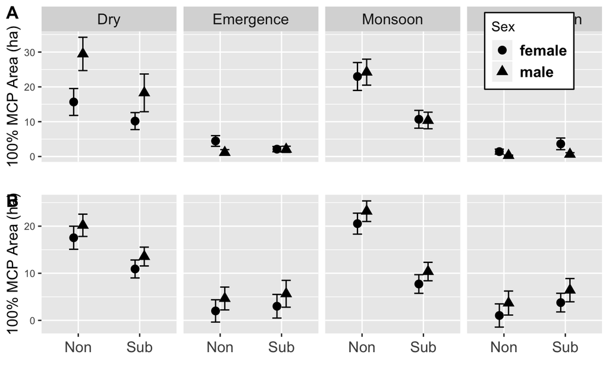

```r
ggarrange(raw.seasonal, adj.seasonal, labels = c("A", "B"),
          nrow = 2)
```

Post hoc analyses of seasonal home ranges

Pairwise of each season between populations, overaged over levels of sex

```r
emm_s.t <- emmeans(RM.mod.Season, pairwise ~ Environment | Season)
emm_s.t
```

Graphical comparisons

```r
plot(emm_s.t, comparisons = TRUE)
```

Pairwise between seasons within each popultion

```r
emm_s.t4 <- emmeans(RM.mod.Season, pairwise ~ Season | Environment)
emm_s.t4
```

Graphical Comps

```r
plot(emm_s.t4, comparisons = TRUE)
```

Pairwise between sexes of each season of the subsidized population

```r
sub <- subset(seasonal, Environment == "subsidized")

RM.mod.Sub <- lmer(Home_Range_100mcp~Season+Sex+N+Season*Sex+(1|Gila), data=sub)

emm_s.t5 <- emmeans(RM.mod.Sub, pairwise ~ Sex | Season)
emm_s.t5
```

Graphical Comps

```r
plot(emm_s.t5, comparisons = TRUE)
```

Pairwise between sexes of each season of the non-subsidized population

```r
nonsub <- subset(seasonal, Environment == "nonsubsidized")
View(nonsub)
RM.mod.NSub <- lmer(Home_Range_100mcp~Season+Sex+N+Season*Sex+(1|Gila), data=nonsub)

emm_s.t6 <- emmeans(RM.mod.NSub, pairwise ~ Sex | Season)
emm_s.t6
```

Graphical Comps

```r
plot(emm_s.t6, comparisons = TRUE)
```